# Stability Assignment

Trevor Maggart, Caroline Shepherd, & Nick McManus

## Overview

For this assignment we are adding hunting of prey to the `lotvmodK.r` function.

We will explore how different hunting levels and different minimum prey populations are likely to effect the stability of the populations of both predator and prey. Then we will use this exploration to recommend a hunting target that will be sustainable.

For this analysis, we will assume the following rprey=0.95, alpha=0.01, eff=0.6,pmort=0.4, K=2000, min_prey_pop=1.

```r
# Our edited model
lotvmodK <- function(t, pop, pars) {
  with(as.list(c(pars, pop)), {
    if (prey < min_prey_pop) {
      dprey <- rprey * (1 - prey / K) * prey - alpha*prey*pred
    } else {
      dprey <- rprey * (1 - prey / K) * prey - alpha*prey*pred - hunt_level*prey
    }
    dpred = eff*alpha*prey*pred - pmort*pred
    return(list(c(prey_growth = dprey,pred_growth = dpred)))})
}
```

### Our stability metric

```r
# Our stability model
stability_metric <- function(res){
  # Create a prey subset
  prey_sub <- res %>%
    filter(animal == 'prey')
  # Create a predator subset
  pred_sub <- res %>%
    filter(animal == 'pred')
  # See if the slopes of the populations for the last 10 days are equal to 0
  if(nrow(prey_sub) >= 10 & nrow(pred_sub) >= 10 &
     round(prey_sub$pop[nrow(prey_sub)]-prey_sub$pop[nrow(prey_sub)-10],0) == 0 &
     round(pred_sub$pop[nrow(pred_sub)]-pred_sub$pop[nrow(pred_sub)-10],0) == 0){
    print("Populations are stable")
  } else{
    print("Populations aren't stable")
  }
}
```

## Exploring different hunting rates (0.25, 0.5, 0.75, 1)

We decided to explore four different hunting rates with a starting population of 1 for both predators and prey. Results show that all hunting rates reach stability except for the rate of 1.

```r
# Set our parameters that will not change throughout
## We chose a three-year period (or 1095 days) for our evaluation time
days = seq(from=1,to=1095)

## Current population of 1 prey and 1 predator
currpop=c(prey=1, pred=1)
```

```r
# Set the parameter list for our first exploration with a hunting level of 0.25
pars = data.frame(rprey=0.95, alpha=0.01, eff=0.6,pmort=0.4, K=2000, hunt_level = 0.25, min_prey_pop = 1)

# Run our ODE solver
res1 = ode(func=lotvmodK, y=currpop, times=days, parms=pars)
res1 = as.data.frame(res1) %>% gather(key="animal", value="pop",-time)

# Create a plot to show later
p_0.25 <- ggplot(res1, aes(time, pop, col=animal)) +
  theme_minimal() +
  geom_line() +
  labs(x = "Days",
       y = "Population") +
  scale_color_manual(values = c("#FF9F1C","#2EC4B6")) +
  theme(
    plot.title = element_text(size = 12, family = "Avenir", face = 'bold'),
    axis.title.x = element_text(size = 12, family = "Avenir", face = 'bold', vjust = -0.5),
    axis.title.y = element_text(size = 12, family = "Avenir", face = 'bold', vjust = 2),
    legend.title = element_text(size = 12, family = "Avenir", face = 'bold'),
    legend.text = element_text(size = 8, family = "Avenir", face = 'bold'),
    legend.background = element_rect(fill="white"),
    legend.justification=c(1,1),
    legend.position=c(0.9,0.9)) +
    ggtitle('hunting rate = 0.25')

# Set the parameter list for our second exploration with a hunting level of 0.5
pars = data.frame(rprey=0.95, alpha=0.01, eff=0.6,pmort=0.4, K=2000, hunt_level = 0.5, min_prey_pop = 1)

# Run our ODE solver
res2 = ode(func=lotvmodK, y=currpop, times=days, parms=pars)
res2 = as.data.frame(res2) %>% gather(key="animal", value="pop",-time)

# Create a plot to show later
p_0.5 <- ggplot(res2, aes(time, pop, col=animal)) +
  theme_minimal() +
  geom_line() +
  labs(x = "Days",
       y = "Population") +
  scale_color_manual(values = c("#FF9F1C","#2EC4B6")) +
  theme(
    plot.title = element_text(size = 12, family = "Avenir", face = 'bold'),
    axis.title.x = element_text(size = 12, family = "Avenir", face = 'bold', vjust = -0.5),
    axis.title.y = element_text(size = 12, family = "Avenir", face = 'bold', vjust = 2),
    legend.title = element_text(size = 12, family = "Avenir", face = 'bold'),
    legend.text = element_text(size = 8, family = "Avenir", face = 'bold'),
    legend.background = element_rect(fill="white"),
    legend.justification=c(1,1),
    legend.position=c(0.9,0.9)) +
    ggtitle('hunting rate = 0.5')

# Set the parameter list for our third exploration with a hunting level of 0.75
pars = data.frame(rprey=0.95, alpha=0.01, eff=0.6,pmort=0.4, K=2000, hunt_level = 0.75, min_prey_pop = 1)

# Run our ODE solver
res3 = ode(func=lotvmodK, y=currpop, times=days, parms=pars)
res3 = as.data.frame(res3) %>% gather(key="animal", value="pop",-time)

# Create a plot to show later
p_0.75 <- ggplot(res3, aes(time, pop, col=animal)) +
  theme_minimal() +
  geom_line() +
  labs(x = "Days",
       y = "Population") +
  scale_color_manual(values = c("#FF9F1C","#2EC4B6")) +
  theme(
    plot.title = element_text(size = 12, family = "Avenir", face = 'bold'),
    axis.title.x = element_text(size = 12, family = "Avenir", face = 'bold', vjust = -0.5),
    axis.title.y = element_text(size = 12, family = "Avenir", face = 'bold', vjust = 2),
    legend.title = element_text(size = 12, family = "Avenir", face = 'bold'),
    legend.text = element_text(size = 8, family = "Avenir", face = 'bold'),
    legend.background = element_rect(fill="white"),
    legend.justification=c(1,1),
    legend.position=c(0.9,0.9)) +
    ggtitle('hunting rate = 0.75')

# Set the parameter list for our fourth exploration with a hunting level of 1
pars = data.frame(rprey=0.95, alpha=0.01, eff=0.6,pmort=0.4, K=2000, hunt_level = 1, min_prey_pop = 1)

# Run our ODE solver
res4 = ode(func=lotvmodK, y=currpop, times=days, parms=pars)
```

```
## DLSODA-  At current T (=R1), MXSTEP (=I1) steps
##       taken on this call before reaching TOUT
## In above message, I1 = 5000
##
## In above message, R1 = 1.00227
##
```

```r
res4 = as.data.frame(res4) %>% gather(key="animal", value="pop",-time)

# Create a plot to show later
p_1 <- ggplot(res4, aes(time, pop, col=animal)) +
  theme_minimal() +
  geom_line() +
  labs(x = "Days",
       y = "Population") +
  scale_color_manual(values = c("#FF9F1C","#2EC4B6")) +
  theme(
    plot.title = element_text(size = 12, family = "Avenir", face = 'bold'),
    axis.title.x = element_text(size = 12, family = "Avenir", face = 'bold', vjust = -0.5),
    axis.title.y = element_text(size = 12, family = "Avenir", face = 'bold', vjust = 2),
    legend.title = element_text(size = 12, family = "Avenir", face = 'bold'),
    legend.text = element_text(size = 8, family = "Avenir", face = 'bold'),
    legend.background = element_rect(fill="white"),
    legend.justification=c(1,1),
    legend.position=c(0.9,0.9)) +
    ggtitle('hunting rate = 1')
```

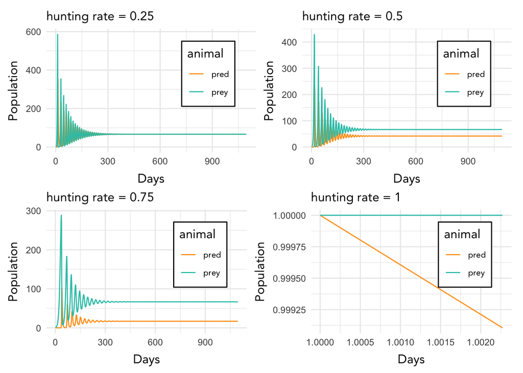

```r
(p_0.25 | p_0.5) / (p_0.75 | p_1)
```

Testing the stability metric for the four scenarios:

```r
stability_metric(res=res1)
```

```
## [1] "Populations are stable"
```

```r
stability_metric(res=res2)
```

```
## [1] "Populations are stable"
```

```r
stability_metric(res=res3)
```

```
## [1] "Populations are stable"
```

```r
stability_metric(res=res4)
```

```
## [1] "Populations aren't stable"
```

We can see that hunting levels 0.25-0.75 show stable populations, and hunting level 1 shows an unstable population as expected. However, we will now check if the function works for an unstable population with more than 10 days of data by subsetting the first hunting level (0.25).

```r
stability_metric(res=res1)
```

```
## [1] "Populations are stable"
```

```r
stability_metric(res=subset(res1, time < 300))
```

```
## [1] "Populations aren't stable"
```

Clearly the function is working as the subset does not show a stable population and this is supported by what we see visually in our graphs.

## Exploring different prey populations (2, 5, 10, 50)

We decided to explore four different starting prey populations using a consistent hunting rate of 0.5 as previous results showed this was stable for a starting population of 1. Results are fairly similar, but stability is reached at different points, and prey populations fluctuate. All scenarios reach stability.

```r
# Choose 4 initial prey populations
currpop_2=c(prey=2, pred=1)
currpop_5=c(prey=5, pred=1)
currpop_10=c(prey=10, pred=1)
currpop_50=c(prey=50, pred=1)

# Set the parameter list for this exploratory analysis
pars = data.frame(rprey=0.95, alpha=0.01, eff=0.6,pmort=0.4, K=2000, hunt_level = 0.5, min_prey_pop = 1)

# Run our ODE solver for currpop_1
res = ode(func=lotvmodK, y=currpop_2, times=days, parms=pars)
res = as.data.frame(res) %>% gather(key="animal", value="pop",-time)

# Create a plot to show later
p_curr_2 <- ggplot(res, aes(time, pop, col=animal)) +
  theme_minimal() +
  geom_line() +
  labs(x = "Days",
       y = "Population") +
  scale_color_manual(values = c("#FF9F1C","#2EC4B6")) +
  theme(
    plot.title = element_text(size = 12, family = "Avenir", face = 'bold'),
    axis.title.x = element_text(size = 12, family = "Avenir", face = 'bold', vjust = -0.5),
    axis.title.y = element_text(size = 12, family = "Avenir", face = 'bold', vjust = 2),
    legend.title = element_text(size = 12, family = "Avenir", face = 'bold'),
    legend.text = element_text(size = 8, family = "Avenir", face = 'bold'),
    legend.background = element_rect(fill="white"),
    legend.justification=c(1,1),
    legend.position=c(0.9,0.9)) +
    ggtitle('prey population = 2')

# Run our ODE solver for currpop_2
res = ode(func=lotvmodK, y=currpop_5, times=days, parms=pars)
res = as.data.frame(res) %>% gather(key="animal", value="pop",-time)

# Create a plot to show later
p_curr_5 <- ggplot(res, aes(time, pop, col=animal)) +
  theme_minimal() +
  geom_line() +
  labs(x = "Days",
       y = "Population") +
  scale_color_manual(values = c("#FF9F1C","#2EC4B6")) +
  theme(
    plot.title = element_text(size = 12, family = "Avenir", face = 'bold'),
    axis.title.x = element_text(size = 12, family = "Avenir", face = 'bold', vjust = -0.5),
    axis.title.y = element_text(size = 12, family = "Avenir", face = 'bold', vjust = 2),
    legend.title = element_text(size = 12, family = "Avenir", face = 'bold'),
    legend.text = element_text(size = 8, family = "Avenir", face = 'bold'),
    legend.background = element_rect(fill="white"),
    legend.justification=c(1,1),
    legend.position=c(0.9,0.9)) +
    ggtitle('prey population = 5')

# Run our ODE solver for currpop_5
res = ode(func=lotvmodK, y=currpop_10, times=days, parms=pars)
res = as.data.frame(res) %>% gather(key="animal", value="pop",-time)

# Create a plot to show later
p_curr_10 <- ggplot(res, aes(time, pop, col=animal)) +
  theme_minimal() +
  geom_line() +
  labs(x = "Days",
       y = "Population") +
  scale_color_manual(values = c("#FF9F1C","#2EC4B6")) +
  theme(
    plot.title = element_text(size = 12, family = "Avenir", face = 'bold'),
    axis.title.x = element_text(size = 12, family = "Avenir", face = 'bold', vjust = -0.5),
    axis.title.y = element_text(size = 12, family = "Avenir", face = 'bold', vjust = 2),
    legend.title = element_text(size = 12, family = "Avenir", face = 'bold'),
    legend.text = element_text(size = 8, family = "Avenir", face = 'bold'),
    legend.background = element_rect(fill="white"),
    legend.justification=c(1,1),
    legend.position=c(0.9,0.9)) +
    ggtitle('prey population = 10')

# Run our ODE solver for currpop_10
res = ode(func=lotvmodK, y=currpop_50, times=days, parms=pars)
res = as.data.frame(res) %>% gather(key="animal", value="pop",-time)

# Create a plot to show later
p_curr_50 <- ggplot(res, aes(time, pop, col=animal)) +
  theme_minimal() +
  geom_line() +
  labs(x = "Days",
       y = "Population") +
  scale_color_manual(values = c("#FF9F1C","#2EC4B6")) +
  theme(
    plot.title = element_text(size = 12, family = "Avenir", face = 'bold'),
    axis.title.x = element_text(size = 12, family = "Avenir", face = 'bold', vjust = -0.5),
    axis.title.y = element_text(size = 12, family = "Avenir", face = 'bold', vjust = 2),
    legend.title = element_text(size = 12, family = "Avenir", face = 'bold'),
    legend.text = element_text(size = 8, family = "Avenir", face = 'bold'),
    legend.background = element_rect(fill="white"),
    legend.justification=c(1,1),
    legend.position=c(0.9,0.9)) +
    ggtitle('prey population = 50')
```

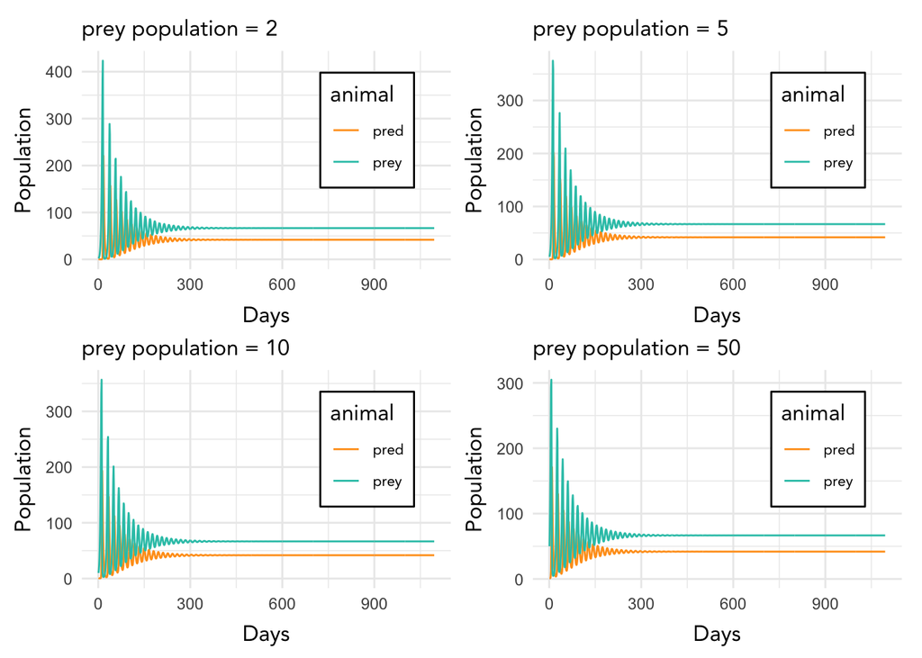

```r
(p_curr_2 | p_curr_5) / (p_curr_10 | p_curr_50)
```

## Analyzing the relationship between prey growth rate and hunting rate

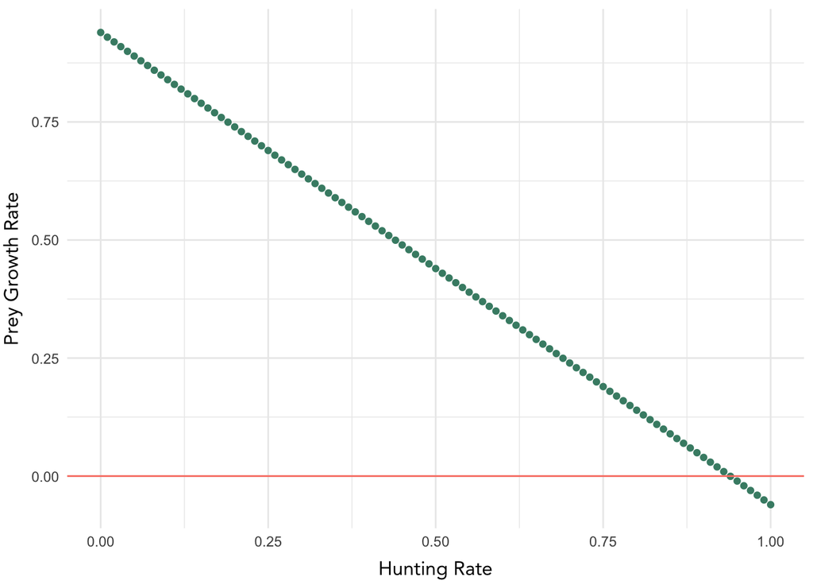

```r
# looking at hunting levels and prey populations
hunt_level <- seq(from = 0, to = 1, by = 0.01)
dpredprey <- map_df(hunt_level, ~lotvmodK(pop = currpop, t = NULL, pars = list(rprey = 0.95, alpha = 0.01, eff = 0.6, pmort = 0.4, K = 2000, min_prey_pop = 1, hunt_level = .x)))

hunt_pop_p = ggplot(data = dpredprey, aes(hunt_level, prey_growth)) +
  theme_minimal() +
  geom_point(col="aquamarine4") +
  geom_hline(yintercept = 0, col="salmon") +
  labs(y="Prey Growth Rate", x="Hunting Rate") +
  theme(
    plot.title = element_text(size = 12, family = "Avenir", face = 'bold'),
    axis.title.x = element_text(size = 12, family = "Avenir", face = 'bold', vjust = -0.5),
    axis.title.y = element_text(size = 12, family = "Avenir", face = 'bold', vjust = 2),
    legend.title = element_text(size = 12, family = "Avenir", face = 'bold'),
    legend.text = element_text(size = 8, family = "Avenir", face = 'bold'),
    legend.background = element_rect(fill="white"),
    legend.justification=c(1,1),
    legend.position=c(0.9,0.9))

hunt_pop_p
```

We defined stability based on the predator and prey population having a slope of 0 near the end of our time frame (the last 10 days of our 3-year period). Depending on the needs of the local ecology and other confounding variables we recommend a hunting rate below of 0.75 or below to maintain stable populations.